# data_exploration

Group 21

2022-10-07

```r
library(rstudioapi)
library(tidyverse)
library(gam)
```

```r
library(splines)
library(splines2)
library(dplyr)
library(tidyr)
library(broom)
library(dslabs)
library(ggplot2)
library(ggthemes)
library(ggrepel)
# data cleaning for socio economic factors
soecon <- read_csv('soecon.csv')
```

```
## ──────────────────────────────────────────────────────── Delimiter: "," chr
## (1): Location dbl (10): ...1, year, SNAP, individual_homeless, fam_homeless,
## total_homeles...
```

```r
fulldat <- read_csv('FullData.csv')
```

```
## ──────────────────────────────────────────────────────── Delimiter: "," chr
## (3): LocationAbbr, LocationDesc, State.Name dbl (39): ...1, YearStart,
## DataValue, LowConfidenceLimit, HighConfidenceLimi...
```

```r
names(fulldat)[names(fulldat) == 'DataValue'] <- 'Asthmap'
names(fulldat)[names(fulldat) == 'TOBDataValue'] <- 'TOB'
```

#### EDA of socioeconomic data

```r
names(soecon)
```

```
##  [1] "...1"                "Location"            "year"
##  [4] "SNAP"                "individual_homeless" "fam_homeless"
##  [7] "total_homeless"      "unemployment_rate"   "Male_poverty"
## [10] "Female_poverty"      "Total_poverty"
```

Run a summary of the variables in socioeconomic category

```r
summary(soecon)
```

```
##       ...1         Location              year           SNAP
##  Min.   :  1.0   Length:459         Min.   :2011   Min.   :  2.431
##  1st Qu.:115.5   Class :character   1st Qu.:2013   1st Qu.: 18.913
##  Median :230.0   Mode  :character   Median :2015   Median : 60.619
##  Mean   :230.0                      Mean   :2015   Mean   : 85.846
##  3rd Qu.:344.5                      3rd Qu.:2017   3rd Qu.: 93.756
##  Max.   :459.0                      Max.   :2019   Max.   :441.777
##                                                    NA's   :1
##  individual_homeless  fam_homeless     total_homeless    unemployment_rate
##  Min.   : 0.0320     Min.   :0.00750   Min.   : 0.0542   Min.   : 2.100
##  1st Qu.: 0.1500     1st Qu.:0.07225   1st Qu.: 0.2377   1st Qu.: 3.900
##  Median : 0.3505     Median :0.16880   Median : 0.5785   Median : 5.000
##  Mean   : 0.7216     Mean   :0.39994   Mean   : 1.1215   Mean   : 5.471
##  3rd Qu.: 0.6794     3rd Qu.:0.39065   3rd Qu.: 1.0424   3rd Qu.: 6.700
##  Max.   :12.8777     Max.   :5.21150   Max.   :15.1278   Max.   :15.800
##
##   Male_poverty    Female_poverty   Total_poverty
##  Min.   :0.0570   Min.   :0.0780   Min.   :0.0700
##  1st Qu.:0.0980   1st Qu.:0.1250   1st Qu.:0.1120
##  Median :0.1140   Median :0.1460   Median :0.1290
##  Mean   :0.1167   Mean   :0.1508   Mean   :0.1341
##  3rd Qu.:0.1360   3rd Qu.:0.1740   3rd Qu.:0.1545
##  Max.   :0.2020   Max.   :0.2610   Max.   :0.2230
##
```

Draw histograms of the variables in the dataset

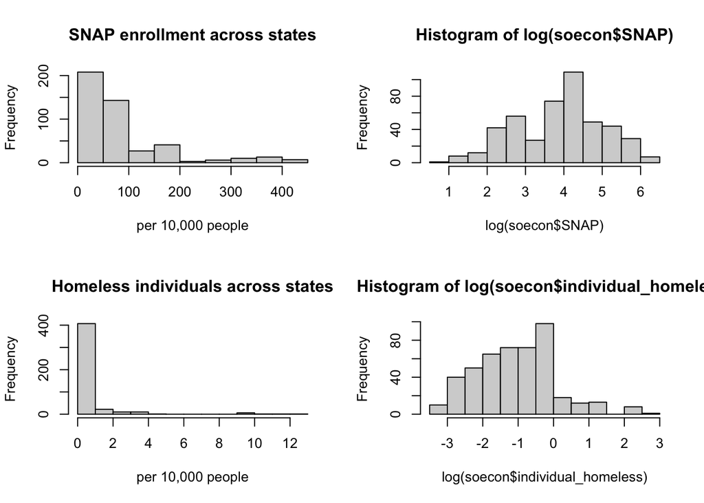

```r
par(mfrow = c(2,2))
hist(soecon$SNAP, main='SNAP enrollment across states', xlab = 'per 10,000 people' )
hist(log(soecon$SNAP))

hist(soecon$individual_homeless, main = 'Homeless individuals across states', xlab = 'per 10,000 people')
hist(log(soecon$individual_homeless))
```

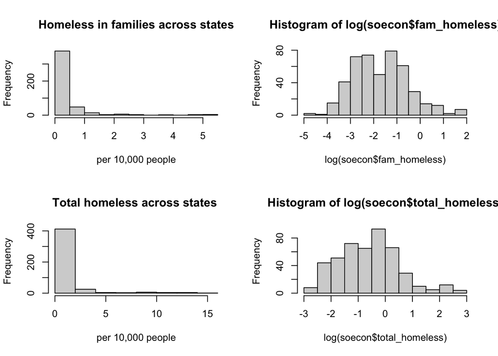

```r
hist(soecon$fam_homeless, main = 'Homeless in families across states', xlab = 'per 10,000 people')
hist(log(soecon$fam_homeless))

hist(soecon$total_homeless, main = 'Total homeless across states ', xlab = 'per 10,000 people')
hist(log(soecon$total_homeless))
```

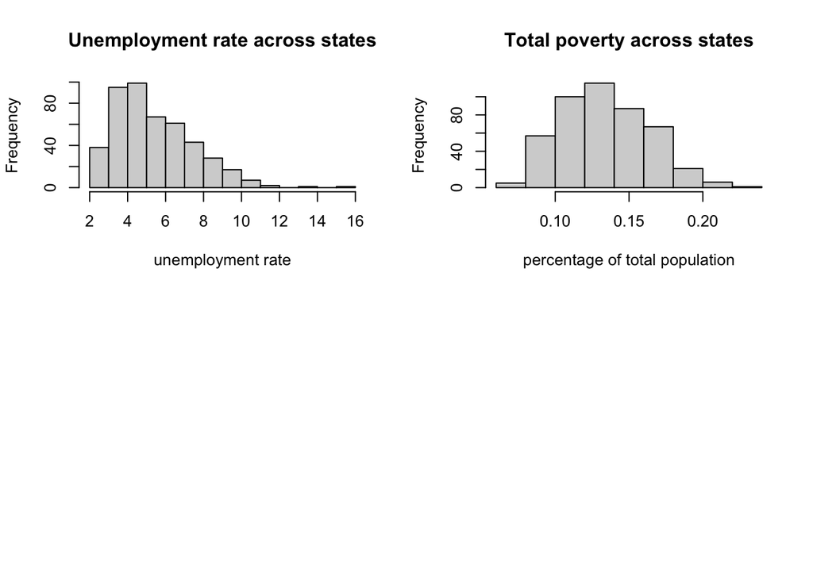

```r
hist(soecon$unemployment_rate, main='Unemployment rate across states', xlab = 'unemployment rate')


hist(soecon$Total_poverty, main='Total poverty across states', xlab = 'percentage of total population')
```

based on the histograms, most of the variables have skewed distribution, but after taking the logarithms of them, they tend to have more normal distribution. This is because most of the variables are population data, and the population values are big, but after taking the logarithms, the values will be more normally distributed.

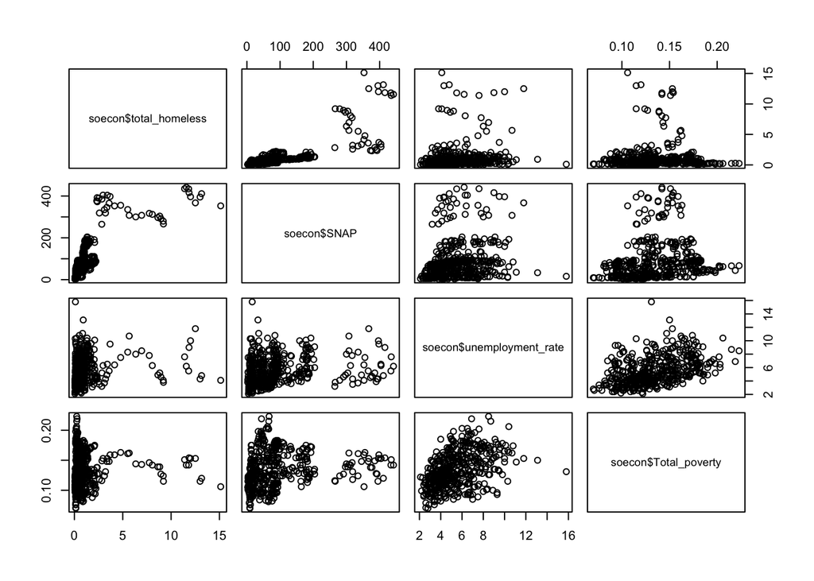

```r
pairs(soecon$total_homeless ~ soecon$SNAP + soecon$unemployment_rate + soecon$Total_poverty )
```

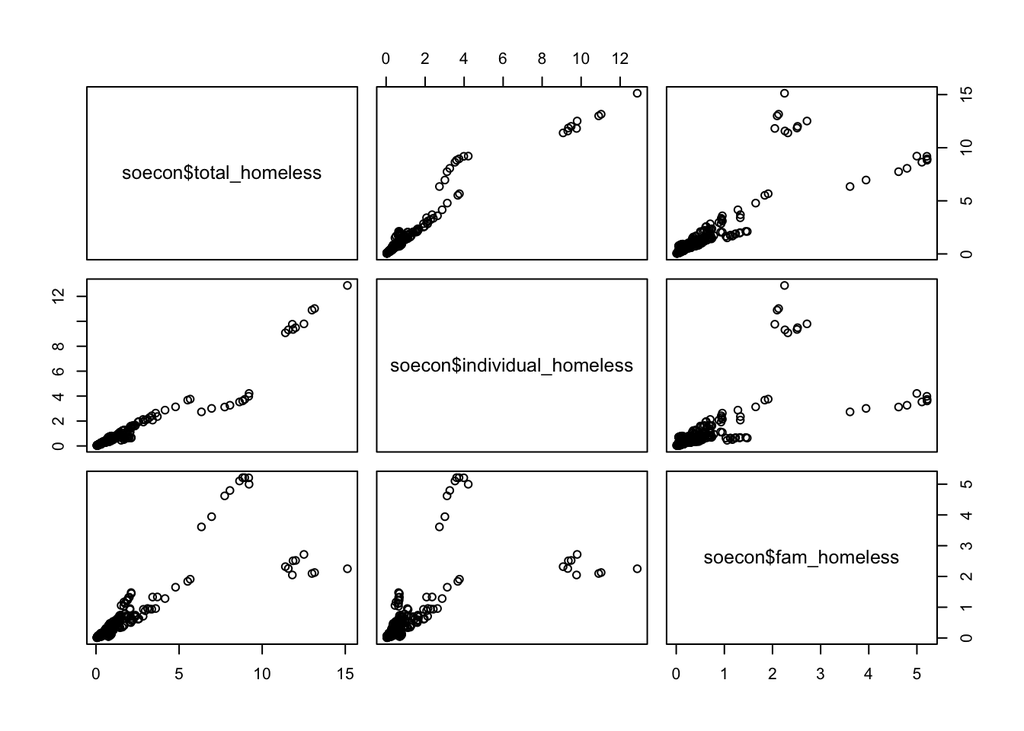

```r
# for the homeless variable, test for colinearity between its three subvariables
pairs(soecon$total_homeless ~ soecon$individual_homeless + soecon$fam_homeless)
```

From the paired scatter plot, we can see that the total number of homeless people is correlated with number os homeless individuals and the number of homeless people in families, so these three variables are not independent with each other.

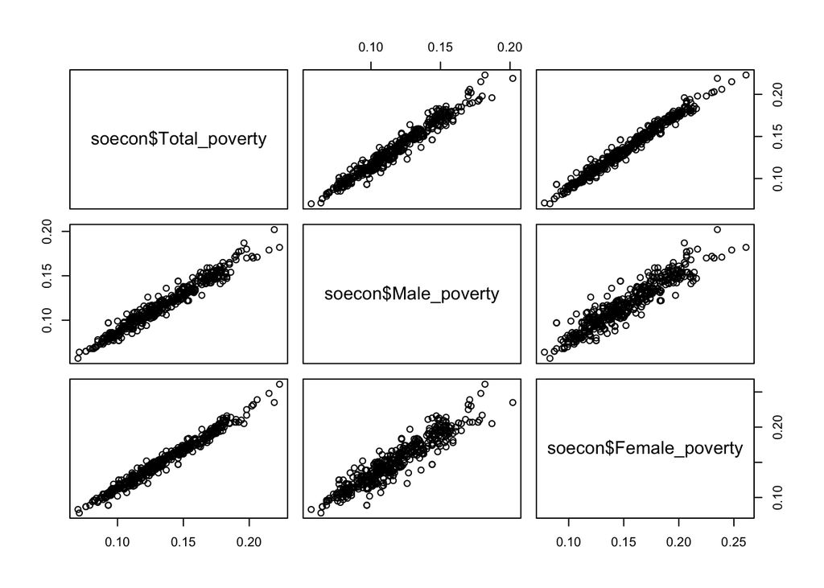

```r
# for the homeless variable, test for colinearity between its three subvariables
pairs(soecon$Total_poverty ~ soecon$Male_poverty + soecon$Female_poverty)
```

By plotting the percentage of males and females that are in poverty in each state against each other, we can see that these variables are linearly correlated with each other and are not independent.

#### EDA for CDI data

```r
names(fulldat[, 1:25])
```

```
##  [1] "...1"                        "YearStart"
##  [3] "LocationAbbr"                "LocationDesc"
##  [5] "Asthmap"                     "LowConfidenceLimit"
##  [7] "HighConfidenceLimit"         "LocationID"
##  [9] "TOB"                         "TOBLowConfidenceLimit"
## [11] "TOBHighConfidenceLimit"      "AlcHeavyDataValue"
## [13] "AlcHeavyLowConfidenceLimit"  "AlcHeavyHighConfidenceLimit"
## [15] "AlcBingeDataValue"           "AlcBingeLowConfidenceLimit"
## [17] "AlcBingeHighConfidenceLimit" "ObeDataValue"
## [19] "ObeLowConfidenceLimit"       "ObeHighConfidenceLimit"
## [21] "selfHlthDataValue"           "selfHlthLowConfidenceLimit"
## [23] "selfHlthHighConfidenceLimit" "HlthCareDataValue"
## [25] "HlthCareLowConfidenceLimit"
```

```r
summary(fulldat[, 4:25])
```

```
##  LocationDesc          Asthmap      LowConfidenceLimit HighConfidenceLimit
##  Length:468         Min.   : 6.10   Min.   : 4.200     Min.   : 8.80
##  Class :character   1st Qu.:10.70   1st Qu.: 8.500     1st Qu.:13.15
##  Mode  :character   Median :12.10   Median : 9.800     Median :14.90
##                     Mean   :12.31   Mean   : 9.972     Mean   :15.15
##                     3rd Qu.:13.80   3rd Qu.:11.350     3rd Qu.:17.00
##                     Max.   :22.20   Max.   :18.000     Max.   :27.00
##                     NA's   :1       NA's   :1          NA's   :1
##    LocationID         TOB        TOBLowConfidenceLimit TOBHighConfidenceLimit
##  Min.   : 1.00   Min.   : 5.80   Min.   : 4.80         Min.   : 7.00
##  1st Qu.:16.75   1st Qu.:14.60   1st Qu.:11.95         1st Qu.:17.50
##  Median :29.50   Median :18.50   Median :15.50         Median :21.80
##  Mean   :29.79   Mean   :18.61   Mean   :15.75         Mean   :21.88
##  3rd Qu.:42.50   3rd Qu.:22.40   3rd Qu.:19.30         3rd Qu.:25.95
##  Max.   :72.00   Max.   :38.30   Max.   :34.50         Max.   :42.20
##                  NA's   :1       NA's   :1             NA's   :1
##  AlcHeavyDataValue AlcHeavyLowConfidenceLimit AlcHeavyHighConfidenceLimit
##  Min.   : 2.500    Min.   : 1.500             Min.   : 3.300
##  1st Qu.: 5.200    1st Qu.: 3.700             1st Qu.: 7.200
##  Median : 6.300    Median : 4.700             Median : 8.300
##  Mean   : 6.383    Mean   : 4.722             Mean   : 8.619
##  3rd Qu.: 7.300    3rd Qu.: 5.500             3rd Qu.: 9.700
##  Max.   :14.300    Max.   :11.400             Max.   :19.500
##  NA's   :3         NA's   :3                  NA's   :3
##  AlcBingeDataValue AlcBingeLowConfidenceLimit AlcBingeHighConfidenceLimit
##  Min.   : 8.40     Min.   : 5.40              Min.   :10.70
##  1st Qu.:15.20     1st Qu.:12.55              1st Qu.:18.20
##  Median :17.90     Median :15.20              Median :21.30
##  Mean   :18.12     Mean   :15.26              Mean   :21.41
##  3rd Qu.:20.80     3rd Qu.:17.70              3rd Qu.:24.30
##  Max.   :32.80     Max.   :27.30              Max.   :39.70
##  NA's   :1         NA's   :1                  NA's   :1
##   ObeDataValue   ObeLowConfidenceLimit ObeHighConfidenceLimit selfHlthDataValue
##  Min.   :39.40   Min.   :34.60         Min.   :43.00          Min.   :78.50
##  1st Qu.:49.50   1st Qu.:45.20         1st Qu.:53.25          1st Qu.:85.85
##  Median :53.40   Median :49.20         Median :57.60          Median :87.80
##  Mean   :53.41   Mean   :49.28         Mean   :57.48          Mean   :87.57
##  3rd Qu.:57.70   3rd Qu.:53.60         3rd Qu.:61.55          3rd Qu.:89.55
##  Max.   :69.40   Max.   :64.70         Max.   :74.10          Max.   :95.30
##  NA's   :1       NA's   :1             NA's   :1              NA's   :1
##  selfHlthLowConfidenceLimit selfHlthHighConfidenceLimit HlthCareDataValue
##  Min.   :72.70              Min.   :81.5                Min.   :59.60
##  1st Qu.:82.90              1st Qu.:88.3                1st Qu.:79.30
##  Median :84.90              Median :90.0                Median :84.50
##  Mean   :84.73              Mean   :89.9                Mean   :83.61
##  3rd Qu.:87.20              3rd Qu.:91.6                3rd Qu.:88.90
##  Max.   :92.90              Max.   :97.0                Max.   :96.50
##  NA's   :1                  NA's   :1                   NA's   :1
##  HlthCareLowConfidenceLimit
##  Min.   :56.40
##  1st Qu.:75.75
##  Median :81.50
##  Mean   :80.47
##  3rd Qu.:85.90
##  Max.   :94.80
##  NA's   :1
```

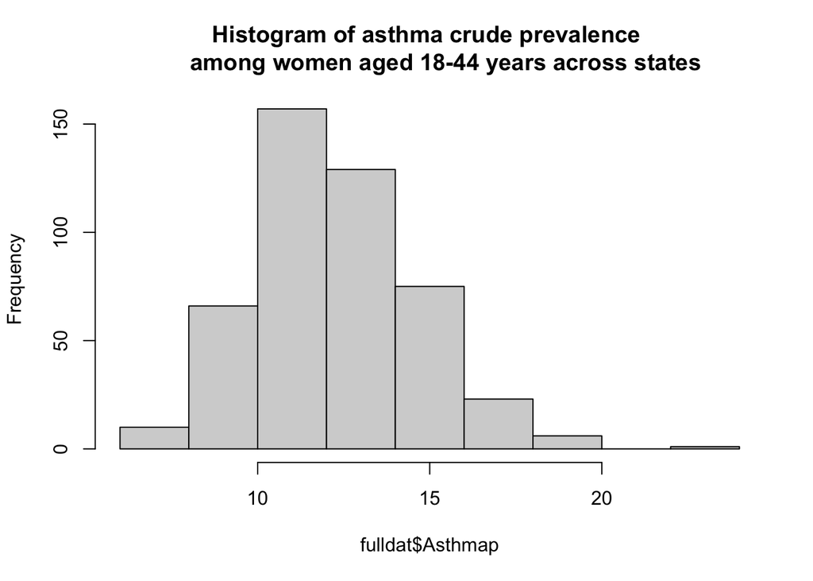

```r
hist(fulldat$Asthmap, main='Histogram of asthma crude prevalence
     among women aged 18-44 years across states' )
```

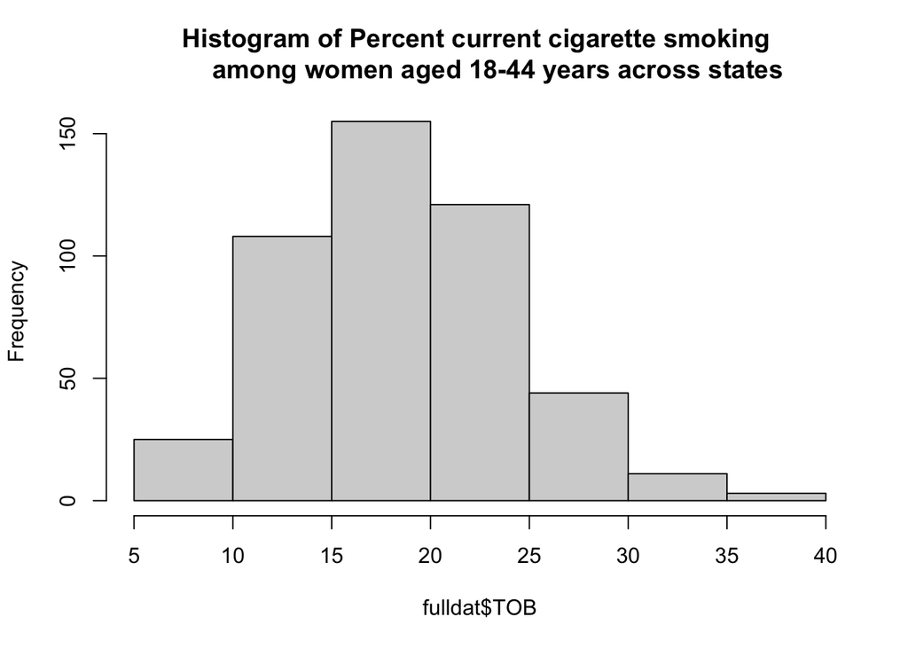

```r
hist(fulldat$TOB, main='Histogram of Percent current cigarette smoking
     among women aged 18-44 years across states')
```

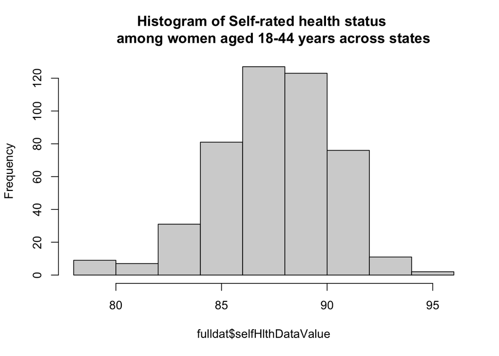

```r
hist(fulldat$selfHlthDataValue, main = 'Histogram of Self-rated health status
     among women aged 18-44 years across states')
```

Based on these histograms, we can see that most of the covariates here are normally distributed with some skewness since they’re data from the realworld.

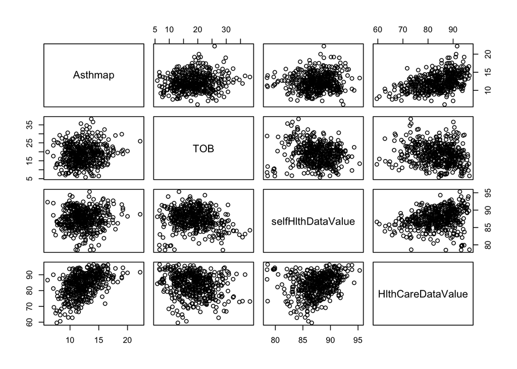

```r
# paired scatter plots of Asthma Prevalence and CDI variables
pairs(Asthmap ~ TOB + selfHlthDataValue + HlthCareDataValue, dat = fulldat)
```

Based on these paired comparisons, we can see that the asthma prevalence has a relatively strong correlation with health care coverage data compared to the other two covariates. It will likely be a confounder that needs to be addressed.

#### EDA for Air Pollution Data

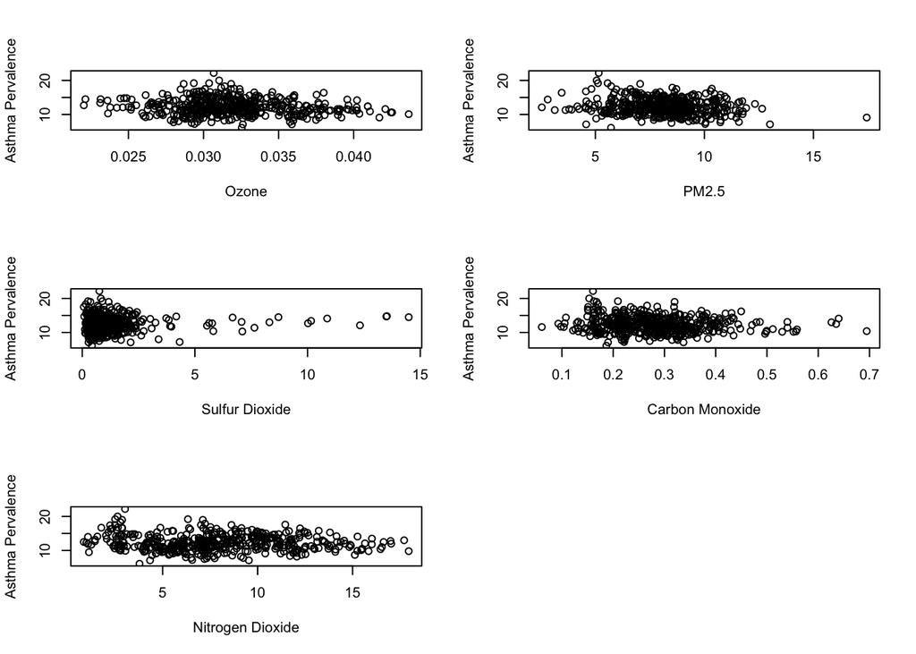

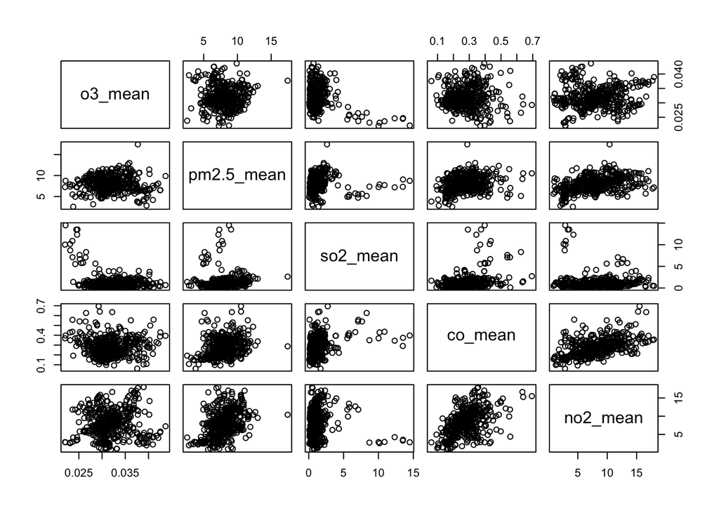

```r
#air pollutant exploratory

par(mfrow = c(3,2))
plot(fulldat$Asthmap ~ fulldat$o3_mean, ylab = "Asthma Pervalence", xlab = "Ozone")
plot(fulldat$Asthmap ~ fulldat$pm2.5_mean,ylab = "Asthma Pervalence", xlab = "PM2.5")
plot(fulldat$Asthmap ~ fulldat$so2_mean,ylab = "Asthma Pervalence", xlab = "Sulfur Dioxide")
plot(fulldat$Asthmap ~ fulldat$co_mean, ylab = "Asthma Pervalence", xlab = "Carbon Monoxide")
plot(fulldat$Asthmap ~ fulldat$no2_mean, ylab = "Asthma Pervalence", xlab = "Nitrogen Dioxide")

pairs(o3_mean ~ pm2.5_mean + so2_mean + co_mean + no2_mean, data = fulldat)
```

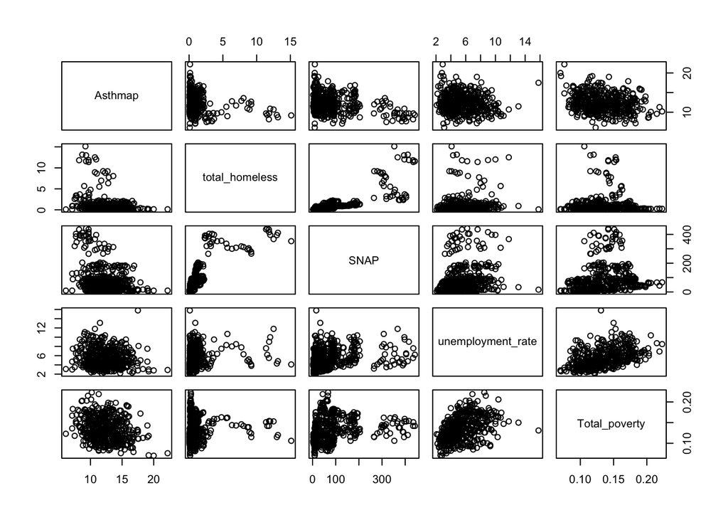

```r
# paired scatter plots of Asthma Pervalence and socioeconomic variables
pairs(Asthmap ~ total_homeless + SNAP + unemployment_rate + Total_poverty, dat = fulldat)
```

#### Forward Selection

```r
# now we try to determine which variable is more significant in predicting the Asthma prevalence
# forward selection
coln <- colnames(fulldat)

coln
```

```
##  [1] "...1"                        "YearStart"
##  [3] "LocationAbbr"                "LocationDesc"
##  [5] "Asthmap"                     "LowConfidenceLimit"
##  [7] "HighConfidenceLimit"         "LocationID"
##  [9] "TOB"                         "TOBLowConfidenceLimit"
## [11] "TOBHighConfidenceLimit"      "AlcHeavyDataValue"
## [13] "AlcHeavyLowConfidenceLimit"  "AlcHeavyHighConfidenceLimit"
## [15] "AlcBingeDataValue"           "AlcBingeLowConfidenceLimit"
## [17] "AlcBingeHighConfidenceLimit" "ObeDataValue"
## [19] "ObeLowConfidenceLimit"       "ObeHighConfidenceLimit"
## [21] "selfHlthDataValue"           "selfHlthLowConfidenceLimit"
## [23] "selfHlthHighConfidenceLimit" "HlthCareDataValue"
## [25] "HlthCareLowConfidenceLimit"  "HlthCareHighConfidenceLimit"
## [27] "X.x"                         "SNAP"
## [29] "individual_homeless"         "fam_homeless"
## [31] "total_homeless"              "unemployment_rate"
## [33] "Male_poverty"                "Female_poverty"
## [35] "Total_poverty"               "X.y"
## [37] "o3_mean"                     "pm2.5_mean"
## [39] "so2_mean"                    "co_mean"
## [41] "no2_mean"                    "State.Name"
```

```r
fulldat <- fulldat |> drop_na()

require(broom)
#forward selection procedure using AIC values
lm1 <- lm(Asthmap ~ 1, data=fulldat)
stepModel <- step(lm1, direction="forward",
scope=(~ selfHlthDataValue + HlthCareDataValue + SNAP+ individual_homeless+fam_homeless+total_homeless+unemployment_rate+Male_poverty+Female_poverty+Total_poverty+o3_mean+pm2.5_mean+so2_mean+co_mean+no2_mean), data=fulldat)
```

```
## Start:  AIC=730.7
## Asthmap ~ 1
##
##                       Df Sum of Sq    RSS    AIC
## + HlthCareDataValue    1    517.58 1843.0 627.51
## + SNAP                 1    234.38 2126.2 688.26
## + Female_poverty       1    168.16 2192.5 701.30
## + Total_poverty        1    156.58 2204.1 703.54
## + individual_homeless  1    141.75 2218.9 706.39
## + Male_poverty         1    132.16 2228.5 708.22
## + total_homeless       1    109.11 2251.5 712.59
## + pm2.5_mean           1     48.19 2312.4 723.94
## + selfHlthDataValue    1     44.27 2316.4 724.66
## + fam_homeless         1     25.34 2335.3 728.12
## + unemployment_rate    1     25.17 2335.5 728.15
## + o3_mean              1     22.64 2338.0 728.61
## + so2_mean             1     18.38 2342.3 729.38
## + co_mean              1     17.73 2342.9 729.50
## + no2_mean             1     12.69 2347.9 730.41
## <none>                             2360.6 730.70
##
## Step:  AIC=627.51
## Asthmap ~ HlthCareDataValue
##
##                       Df Sum of Sq    RSS    AIC
## + individual_homeless  1    89.073 1754.0 608.46
## + total_homeless       1    74.204 1768.8 612.05
## + SNAP                 1    73.805 1769.2 612.14
## + unemployment_rate    1    27.231 1815.8 623.19
## + fam_homeless         1    24.571 1818.5 623.81
## + so2_mean             1     9.664 1833.4 627.28
## <none>                             1843.0 627.51
## + no2_mean             1     8.485 1834.6 627.55
## + Female_poverty       1     7.001 1836.0 627.89
## + Total_poverty        1     5.343 1837.7 628.28
## + selfHlthDataValue    1     4.820 1838.2 628.40
## + Male_poverty         1     3.225 1839.8 628.77
## + co_mean              1     1.851 1841.2 629.09
## + pm2.5_mean           1     0.235 1842.8 629.46
## + o3_mean              1     0.067 1843.0 629.50
```

[output cut: 73 more lines]

```
## Step:  AIC=583.7
## Asthmap ~ HlthCareDataValue + individual_homeless + unemployment_rate +
##     Female_poverty + selfHlthDataValue + no2_mean
##
##                  Df Sum of Sq    RSS    AIC
## <none>                        1623.8 583.70
## + pm2.5_mean      1    6.9724 1616.9 583.87
## + SNAP            1    3.9647 1619.9 584.66
## + Male_poverty    1    2.1987 1621.7 585.12
## + Total_poverty   1    2.1634 1621.7 585.13
## + so2_mean        1    1.4531 1622.4 585.32
## + co_mean         1    1.0612 1622.8 585.42
## + fam_homeless    1    0.9777 1622.9 585.44
## + total_homeless  1    0.9777 1622.9 585.44
## + o3_mean         1    0.1881 1623.7 585.65
```

From the results of forward selection, we can roughly have an idea on which covariates may have a stronger effect as a confounder. We can see that the variables that we may need to include in our final model are: health care coverage data, homeless percentage, unemployment rate, poverty rate, self-rated health status and $NO_2$ level.